# Genetic Interaction Exploration based on MSI status

Martin Brand

Kathi Zarnack

2023-01-02 - 2023-06-29

Abstract

The workflow explores genetic interactions in cell lines with microsatellite instability. It uses MSI status data provided by Chan et al. Using the gene-screening datasets, it then compares the two samples to identify significant differences in gene dependencies.

```r
Sys.setenv(LANG = "en")
library(dplyr)
library(ggplot2)
library(kableExtra)
library(matrixTests)
library(limma)
library(ggrepel)
library(gridExtra)
library(ComplexHeatmap)
library(readxl)
```

# Target gene

First, we define the target genes to be displayed in the volcano plots.

```r
target.genes <- c("WRN")
```

# Data preprocessing

We load the MSI status dataset ([CCLE MSI status dataset](https://www.nature.com/articles/s41586-019-1102-x#Sec32)) provided by Chan et al. (2019) and the datasets that contains the dependency scores from the projects Achilles and DRIVE ([DepMap datasets](https://figshare.com/articles/dataset/DepMap_Datasets_for_WRN_manuscript/7712756/1)).

```r
# specify the path to the MSI status dataset and to the gene-screening datasets
path <-
  "C:/Users/Martin/Documents/Master/Thesis/genetic_dependency_detection/data/"

# load MSI status dataset
MSI.status <- read_excel(paste0(path, "supplementary_table.xlsx"))
MSI.status <- MSI.status[,c(1,4)]

# load Achilles and DRIVE
dep.scores.DRIVE <- readRDS(paste0(path,"dep.scores.DRIVE.rds"))
dep.scores.Achilles <- readRDS(paste0(path,"dep.scores.Achilles.rds"))

rm(path)
```

```r
source("helper_functions/calc.mean.diffs.and.p.values.R")
source("helper_functions/create_volcano_plot.R")
```

# Classification

We create two samples. One sample contains the MSI cell lines and the other contains the MSS cell lines. We summarize the samples in a classification table. For illustration, we show the beginning of the classification table for the cell lines in the DRIVE dataset.

```r
# convert MSI status information to classification table
class.table <- MSI.status
class.table <- class.table %>% mutate(
  isDeleterious = case_when(CCLE_MSI == "MSI" ~ T, CCLE_MSI == "MSS" ~ F))
class.table$CCLE_MSI <- NULL
class.table <- na.omit(class.table)

# keep only cell lines that appear in the gene-screening dataset and
# the MSI status dataset
class.table.DRIVE <- merge(class.table, dep.scores.DRIVE['CCLE_ID'],
                           by="CCLE_ID")
class.table.Achilles <- merge(class.table, dep.scores.Achilles['CCLE_ID'],
                           by="CCLE_ID")

rm(MSI.status)

# show a table as an example
class.table.DRIVE %>%
  head() %>%
  kbl(caption = "Classification Table in DRIVE",
      col.names = c("CCLE_ID","MSI")) %>%
  kable_styling()
```

Table 1: Classification Table in DRIVE

| CCLE_ID | MSI |
| --- | --- |
| 2313287_STOMACH | TRUE |
| 697_HAEMATOPOIETIC_AND_LYMPHOID_TISSUE | FALSE |
| 769P_KIDNEY | FALSE |
| 786O_KIDNEY | FALSE |
| 8305C_THYROID | FALSE |
| 8505C_THYROID | FALSE |

# Comparison between MSI and MSS cell lines

We calculate the mean values of the dependency scores of both samples, take the difference and calculate the p-value using different statistical tests.

## Welch’s t-test

```r
res <- calc.mean.diffs.and.p.values(
  dep_scores_DRIVE = dep.scores.DRIVE,
  dep_scores_Achilles = dep.scores.Achilles,
  CCLE_mut_DRIVE = class.table.DRIVE,
  CCLE_mut_Achilles = class.table.Achilles)

rm(class.table.DRIVE, class.table.Achilles, class.table, dep.scores.DRIVE,
   dep.scores.Achilles)
```

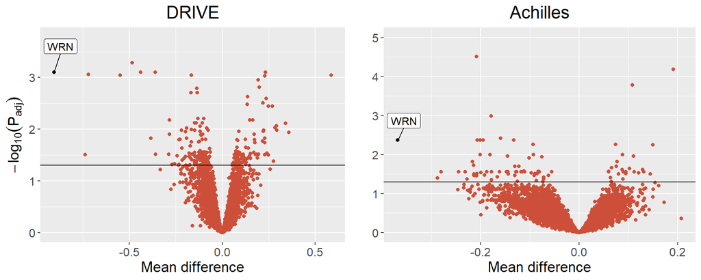

```r
plot.welch.DRIVE <- create_volcano_plot(test_results = res,
                                        dataset = "DRIVE",
                                        test_method = "welch",
                                        labeled_genes = target.genes)

plot.welch.Achilles <- create_volcano_plot(test_results=res,
                                        dataset = "Achilles",
                                        test_method = "welch",
                                        labeled_genes = target.genes,
                                        show_y_label = F)

grid.arrange(plot.welch.DRIVE, plot.welch.Achilles, ncol = 2)
```

```r
rm(plot.welch.DRIVE, plot.welch.Achilles)
```

## Wilcoxon ranked-sum test

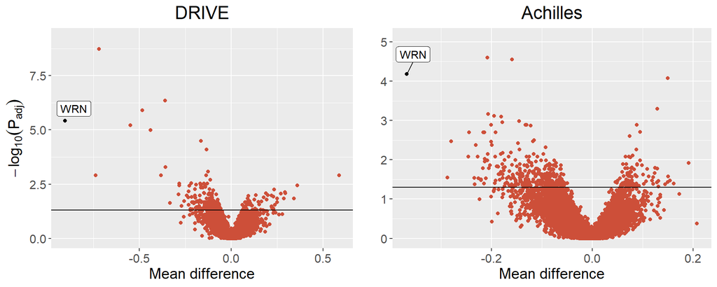

```r
plot.wilc.DRIVE <- create_volcano_plot(test_results = res,
                                       dataset = "DRIVE",
                                       test_method = "wilc",
                                       labeled_genes = target.genes)

plot.wilc.Achilles <- create_volcano_plot(test_results = res,
                                       dataset = "Achilles",
                                       test_method = "wilc",
                                       labeled_genes = target.genes,
                                       show_y_label = F)

grid.arrange(plot.wilc.DRIVE, plot.wilc.Achilles, ncol = 2)
```

```r
rm(plot.wilc.DRIVE, plot.wilc.Achilles)
```

## Bayes moderated t-test

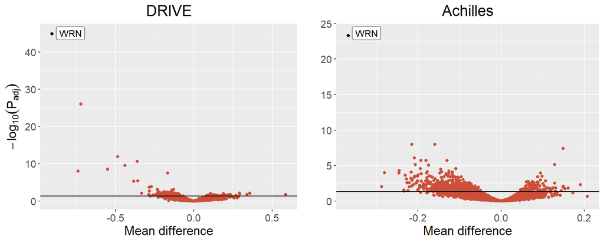

```r
plot.bayes.DRIVE <- create_volcano_plot(test_results = res,
                                       dataset = "DRIVE",
                                       test_method = "bayes",
                                       labeled_genes = target.genes)

plot.bayes.Achilles <- create_volcano_plot(test_results = res,
                                       dataset = "Achilles",
                                       test_method = "bayes",
                                       labeled_genes = target.genes,
                                       show_y_label = F)

grid.arrange(plot.bayes.DRIVE, plot.bayes.Achilles, ncol = 2)
```

```r
rm(plot.bayes.DRIVE, plot.bayes.Achilles, target.genes)
```